# individual1

# Lab 3 - Madalyn Mueller

```r
dat <- readxl::read_xls('/Users/maddiemueller/Desktop/GSS.xls')
dat
```

```
## # A tibble: 64,816 x 10
##    `Gss year for t… `General happin… `Political part… `Respondents se…
##               <dbl> <chr>            <chr>            <chr>
##  1             1972 Not too happy    Ind,near dem     Female
##  2             1972 Not too happy    Not str democrat Male
##  3             1972 Pretty happy     Independent      Female
##  4             1972 Not too happy    Not str democrat Female
##  5             1972 Pretty happy     Strong democrat  Female
##  6             1972 Pretty happy     Ind,near dem     Male
##  7             1972 Not too happy    Ind,near dem     Male
##  8             1972 Not too happy    Ind,near dem     Male
##  9             1972 Pretty happy     Strong democrat  Female
## 10             1972 Pretty happy     Strong democrat  Female
## # … with 64,806 more rows, and 6 more variables: `Highest year of school
## #   completed` <chr>, `Number of children` <chr>, `Marital status` <chr>,
## #   `Number of hours usually work a week` <chr>, `Respondent id number` <dbl>,
## #   `Ballot used for interview` <chr>
```

```r
library(dplyr)
```

```r
library(ggplot2)
```

```r
dat <- dat %>% rename(gssyear = 'Gss year for this respondent', happiness = 'General happiness', party = 'Political party affiliation', sex = 'Respondents sex', school = 'Highest year of school completed', kids = 'Number of children', married = 'Marital status', work = 'Number of hours usually work a week', id = 'Respondent id number', ballot = 'Ballot used for interview')
dat <- dat %>%
  mutate(school = as.numeric(school)) %>% na.omit
```

## 1) Find the average years of education for the respondents with each marital status. Arrange your output in a meaningful order and print. Describe any patterns you find.

```r
education <-
  dat %>%
    group_by(married) %>%
    summarize(aveschool = mean(school))
education
```

```
## # A tibble: 6 x 2
##   married       aveschool
##   <chr>             <dbl>
## 1 Divorced           13.1
## 2 Married            13.0
## 3 Never married      13.4
## 4 No answer          15.5
## 5 Separated          11.9
## 6 Widowed            11.2
```

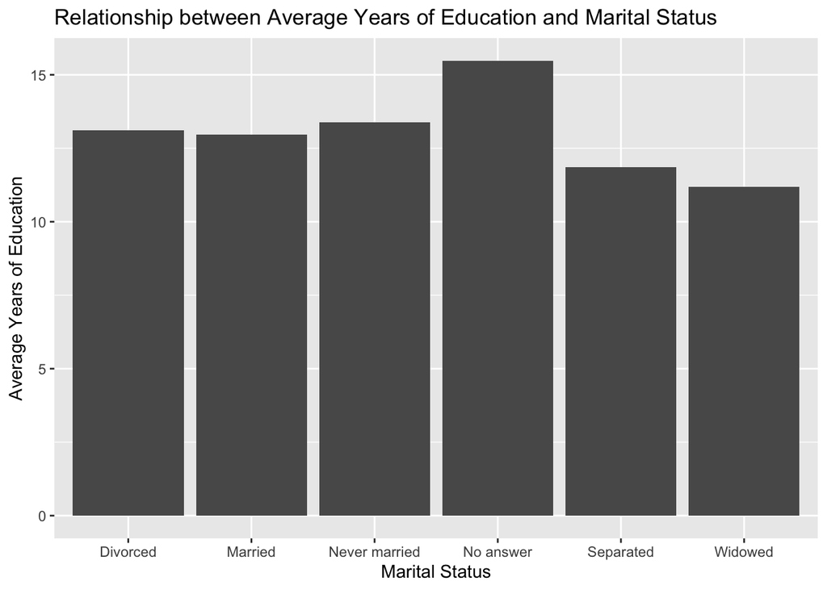

```r
ggplot(education, aes(x=married, weight=aveschool))+geom_bar()+xlab('Marital Status')+ylab('Average Years of Education')+ggtitle('Relationship between Average Years of Education and Marital Status')
```

It appears that those who opted out of answering had the highest average years of schooling out of all of the marriage statuses. Of the people that did respond to this question, those who were widowed had the least amount of school and those who were never married had the highest amount of schooling.

## 2) Create a single data frame containing records for the better educated respondents with each marital status. A “better educated” respondent is someone who has strictly more years of education than the average among those with the same marital status. Print the structure of the data frame.

```r
highed <- filter(dat, school >= education$aveschool & married == 'Divorced', school >= education$aveschool & married == 'Married', school >= education$aveschool & married == 'Never Married', school >= education$aveschool & married == 'No Answer', school >= education$aveschool & married == 'Separated', school >= education$aveschool & married == 'Widowed')
highed
```

```
## # A tibble: 0 x 10
## # … with 10 variables: gssyear <dbl>, happiness <chr>, party <chr>, sex <chr>,
## #   school <dbl>, kids <chr>, married <chr>, work <chr>, id <dbl>, ballot <chr>
```

## 3) How is the happiness of a respondent related to his/her marriage status? Define that a person is happy if the response to question is “Very happy” or “Pretty happy”.

```r
dat %>%
  group_by(married) %>% summarize(happiness)
```

```
## # A tibble: 64,637 x 2
## # Groups:   married [6]
##    married  happiness
##    <chr>    <chr>
##  1 Divorced Not too happy
##  2 Divorced Not too happy
##  3 Divorced Very happy
##  4 Divorced Pretty happy
##  5 Divorced Very happy
##  6 Divorced Not too happy
##  7 Divorced Not too happy
##  8 Divorced Pretty happy
##  9 Divorced Not too happy
## 10 Divorced Pretty happy
## # … with 64,627 more rows
```

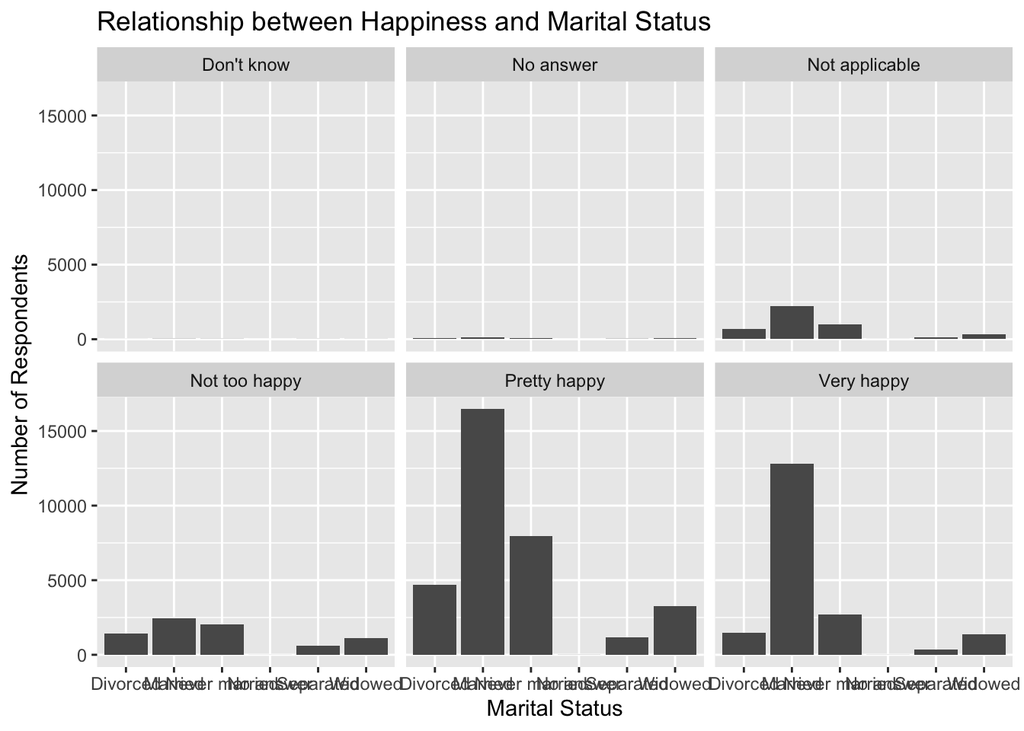

```r
ggplot(dat, aes(x = married)) + geom_bar() + facet_wrap(~ happiness)+xlab('Marital Status')+ylab('Number of Respondents')+ggtitle('Relationship between Happiness and Marital Status')
```

Most people, regardless of marital status, are happy. Married people seem to be the happiest people. They are also the largest column in the “Not too happy” graph. Those who were never married appear to be the second happiest people. It appears that happiness doesn’t relate to marital status based on this data.

## 4) Does party affiliation affect the relationship you found in the last question?

```r
dat %>% group_by(party) %>% count(happiness)
```

```
## # A tibble: 55 x 3
## # Groups:   party [10]
##    party        happiness          n
##    <chr>        <chr>          <int>
##  1 Don't know   Not too happy      3
##  2 Don't know   Pretty happy       3
##  3 Don't know   Very happy         5
##  4 Ind,near dem Don't know         4
##  5 Ind,near dem No answer         37
##  6 Ind,near dem Not applicable   438
##  7 Ind,near dem Not too happy   1062
##  8 Ind,near dem Pretty happy    4316
##  9 Ind,near dem Very happy      1922
## 10 Ind,near rep Don't know         4
## # … with 45 more rows
```

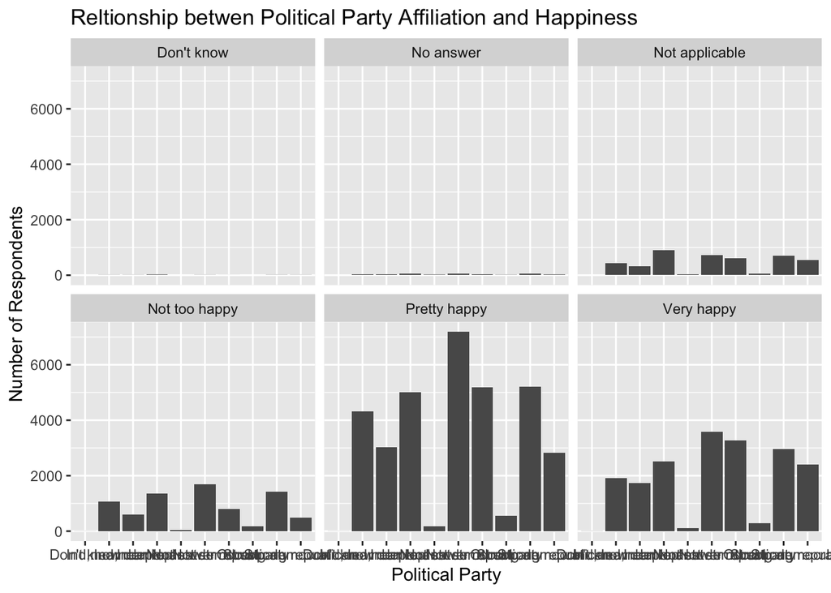

```r
ggplot(dat, aes(x = party)) + geom_bar() + facet_wrap(~ happiness) + ylab("Number of Respondents") + xlab("Political Party")+ggtitle('Reltionship betwen Political Party Affiliation and Happiness')
```

## 5) How is marital status related to the education of a respondent? What are possible reasons accounting for the patterns you see?

```r
education %>%
  group_by(married) %>% summarize(aveschool)
```

```
## # A tibble: 6 x 2
##   married       aveschool
##   <chr>             <dbl>
## 1 Divorced           13.1
## 2 Married            13.0
## 3 Never married      13.4
## 4 No answer          15.5
## 5 Separated          11.9
## 6 Widowed            11.2
```

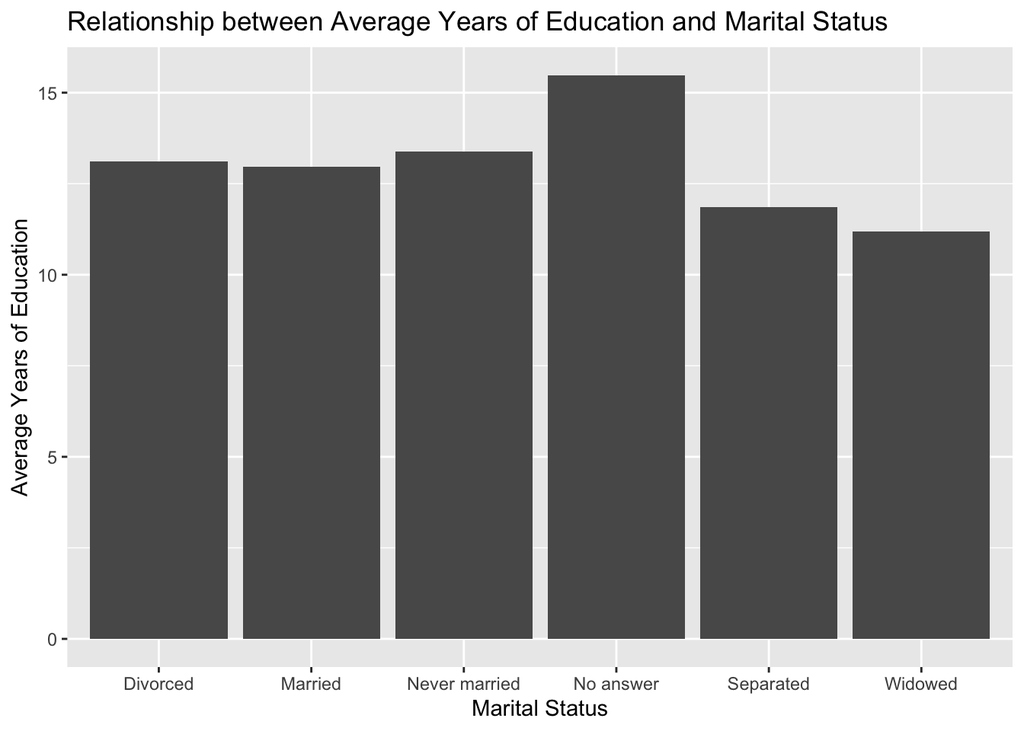

```r
ggplot(education, aes(x=married, weight=aveschool))+geom_bar()+xlab('Marital Status')+ylab('Average Years of Education')+ggtitle('Relationship between Average Years of Education and Marital Status')
```

## 6) Explore two more interesting questions, and answer those questions using the GSS data.

First, we are going to examine if the number of children has an effect on happiness.

```r
dat %>%
group_by(kids) %>%
count(kids)
```

```
## # A tibble: 10 x 2
## # Groups:   kids [10]
##    kids              n
##    <chr>         <int>
##  1 0             17621
##  2 1             10276
##  3 2             16041
##  4 3             10079
##  5 4              5218
##  6 5              2391
##  7 6              1229
##  8 7               673
##  9 Dk na           171
## 10 Eight or more   938
```

```r
dat %>%
group_by(kids) %>%
count(happiness)
```

```
## # A tibble: 60 x 3
## # Groups:   kids [10]
##    kids  happiness          n
##    <chr> <chr>          <int>
##  1 0     Don't know         7
##  2 0     No answer        102
##  3 0     Not applicable  1155
##  4 0     Not too happy   2039
##  5 0     Pretty happy    9727
##  6 0     Very happy      4591
##  7 1     Don't know         3
##  8 1     No answer         47
##  9 1     Not applicable   748
## 10 1     Not too happy   1263
## # … with 50 more rows
```

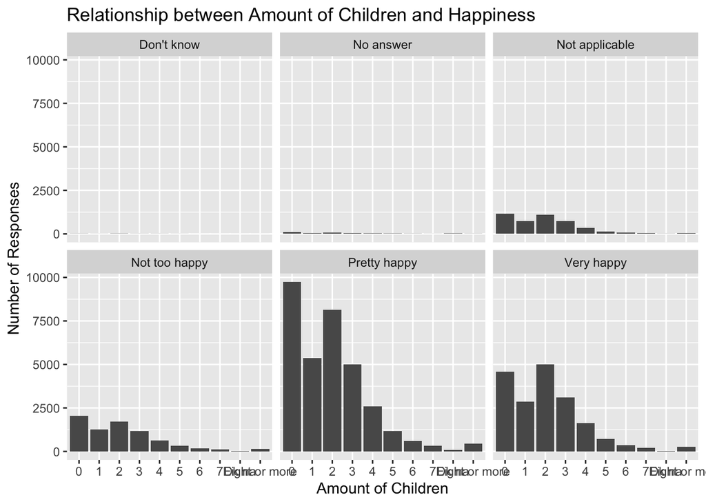

```r
ggplot(dat, aes(x = kids)) + geom_bar() + facet_wrap(~ happiness) + ylab('Number of Responses') + xlab('Amount of Children')+ggtitle('Relationship between Amount of Children and Happiness')
```

It looks like people with less children are the happiest by looking at the graph. When actually, if you get percentages of people who said they were happy based on how many children that they have, they were all around 80%. Based on looking at the amount happiness responses and the ratio of happy people, those who have 2 children seemed to be the most happy, while those with 7 or 8+ children seem to be the least happy, but they were all so close. Based on this data, I don’t think the amount of children has an effect on happiness.

Now we are going to see if the sex of a person has an effect on happiness.

```r
dat %>%
group_by(sex) %>%
count(sex)
```

```
## # A tibble: 2 x 2
## # Groups:   sex [2]
##   sex        n
##   <chr>  <int>
## 1 Female 36095
## 2 Male   28542
```

```r
dat %>%
group_by(sex) %>%
count(happiness)
```

```
## # A tibble: 12 x 3
## # Groups:   sex [2]
##    sex    happiness          n
##    <chr>  <chr>          <int>
##  1 Female Don't know        22
##  2 Female No answer        190
##  3 Female Not applicable  2434
##  4 Female Not too happy   4296
##  5 Female Pretty happy   18492
##  6 Female Very happy     10661
##  7 Male   Don't know        16
##  8 Male   No answer        131
##  9 Male   Not applicable  1934
## 10 Male   Not too happy   3350
## 11 Male   Pretty happy   14991
## 12 Male   Very happy      8120
```

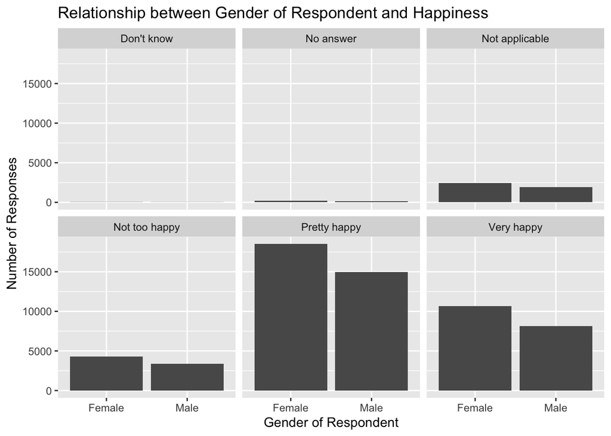

```r
ggplot(dat, aes(x = sex)) + geom_bar() + facet_wrap(~ happiness) + ylab('Number of Responses') + xlab('Gender of Respondent')+ggtitle('Relationship between Gender of Respondent and Happiness')
```

It appears that females are the happiest based on looking at the graph, but if you look at the number of people in the data set there are way more females. It looks like females are the most unhappy as well, but I think that this is because there are way more females in the data set. Therefore, sex does not have an effect on happiness.